### Overview

The Cambodia Agriculture Survey Data Explorer is a utility for policy analysis, progress tracking, comparison, and reporting. It is designed to be extensively user-modifiable so that commonly used graphics can be quickly regenerated from a new data release, reducing the time between collection and analysis. A public version of the app is available https://evans-par.shinyapps.io/agquery and can be used to immediately access the data and produce visualizations. The next section will explain how to download your own copy in order to make best use of these features, and the following sections will provide an instructions on using and updating the content in each tab.

This app is built using Posit’s R Shiny framework. More information on Shiny can be found https://shiny.posit.co/r/getstarted/shiny-basics/lesson1/

### Accessing the App: Online vs Offline Access

To take full advantage of the features of the app, it is necessary to either run your own copy locally or host your own instance using your own server framework or the shinyapps.io service.

#### Requirements for downloading and running a local copy

- First time R users: download and install [R](https://cran.rstudio.com/) and [RStudio.](https://posit.co/download/rstudio-desktop/)
- Existing R users: ensure you are running R version 4.4 or higher and download RStudio if needed.
- Download the latest release at the [Git repository](https://github.com/EvansSchoolPolicyAnalysisAndResearch/50x30_AQP).
- Follow the instructions in the [repository readme](https://github.com/EvansSchoolPolicyAnalysisAndResearch/50x30_AQP/blob/main/README.md) to finish first time setup. After setup is complete, run the app on your computer by opening the R project and the app.R files in RStudio and pressing the “run app” button that appears in the top right-hand corner of the file pane.

#### Sharing your copy with others

If you make modifications to the app and want others to see them, you can create an online version by signing up for an account at https://www.shinyapps.io/. Once you have an account, you can publish your version of the app by pressing the blue button next to “Run App” button. In the dialog box that appears, press “Add new account” to log in to your shinyapps.io account, then press “Publish”. You may be prompted to install additional packages the first time you do this. Apps created with the free tier of the shinyapps account may be limited in the number of simultaneous users.

[figure not shown]

#### Requirements for Self-Hosting

The app can be self-hosted on a server using Docker. Install Docker on your server, clone the directory from github, and build using the included Dockerfile. For more information, see [this guide](https://www.appsilon.com/post/r-shiny-docker-getting-started).

### Updating the App

Follow the instructions below to make your own updates to the app. These steps require following “Requirements for downloading and running a local copy” and assume you are making the changes in your copy of the app.

#### Directory Layout

| └── agquery/ | *Root folder* |
| --- | --- |
| ├── Data | *Processed survey data* |
| ├── Extdata | *Externally sourced data, e.g. World Bank Development indicator CSV files* |
| ├── Commodities | *User-defined folders for data/images related to particular agricultural commodities* |
| └── World Bank | *Datasets sourced from the World Bank for display in value boxes on the Economics tab* |
| ├── renv | *Project R package library* |
| ├── Scripts | *Additional code required by the app, includes functions for processing data and creating charts* |
| ├── Spatial | *Spatial information (rasters and shapefiles) for maps* |
| ├── Update | *Metadata for the survey data folder; update the files in here to change the policy goals and variables.* |
| └── www | *Additional files used in web pages* |

#### Adding Your Own Data

Additional data can be added to the app by placing CSV files with raw data in the Data subfolder. The following requirements must be met for data files to be usable by the app:

- The file name must be “Cambodia_CAS_{YEAR}_{UNIQUENAME}.csv. The unique name must be consistent across survey years.
- The files must contain the **ID variables** “hhid”, “province”, and “zone”. Province can be numeric or string (preference is currently for numeric), while zone should be string.
- Variables in the data files can be named with a combination of letters, numbers, and underscores. They should not include spaces or begin with numbers. Variable names are case sensitive: the names “Chickens” and “chickens” will be treated as different variables. Khmer script is permitted.
- All variables should be numeric; including string or categorical data will result in errors or estimates that are difficult to interpret. Consider adding them to the app as grouping variables instead.

Two additional files, weights.csv and groups.csv, should follow the same file naming convention outlined above and are used to store the household-level weights and any categorical or grouping variables, respectively. Both files are optional; if they are not included, all data files should include weights and grouping criteria. If weights are not found, the numbers presented in the app will represent the unweighted (sample) totals and means.

#### Important Definitions

In order to facilitate analysis and objective formulation related to existing or proposed policies, updating the app requires providing connections between the information collected in the survey and the policy environment within which the analyst is working. Thus, it is necessary to understand the following terms: - **Variable**s or **Indicator**s (the latter term being used mainly in the context of assessing progress toward a development objective) are discrete items measured by the survey, or constructed from a combination of survey-measured items. Examples include the number of chickens, total rice sale value, or livestock mortality rate. Variables are present in the raw data files (at the household level) and summarized to the province, zone, or national level by the app. They are described in the indicators.xlsx spreadsheet. - **Policy Goals** are the broad **outcomes** that a government entity is trying to produce. An ideal policy goal addresses a single topic; examples include improving incomes for cashew producers, increasing the number of poultry-producing households, or reducing postharvest losses of rice. - **Policy Pathways** are means of achieving a goal. A pathway represents a targeted intervention that could conceivably be addressed through a law or rule, or by a program created by an NGO. Examples include (with respect to increasing the number of poultry-producing households) reducing the cost of chicken feed or (with respect to improving cashew producer incomes) increasing access to nut processing equipment. Each **policy goal** could have many **policy pathways** associated with it. - **Instruments** and **Implementation** describe how the policy pathway is actually developed through rulemaking or legislation. An instrument is a generic category for an intervention, such as a subsidy, an information program or public awareness campaign, or a regulation. The implementation describes how the generic instrument is applied to a specific policy pathway, such as reducing feed cost by providing a subsidy for feed or increasing access to processing equipment via a public awareness campaign designed to inform producers about public processing facilities. Each **policy pathway** can be targeted using multiple instruments, and instruments can be implemented in multiple ways.

In practice, variables are associated with multiple policy goals and pathways, and each pathway contains a subset of the variables responsive to the broader policy goal. Associating variables with pathways is optional, but it can help users navigating the app by providing a subset of highly relevant variables without having to dig through all of the available information. When assigning variables to goals or pathways, consider what someone would want to know when deciding whether to focus on a given goal or promoting a particular policy intervention. What variables tell them who their stakeholders are, or whether the intervention is successful?

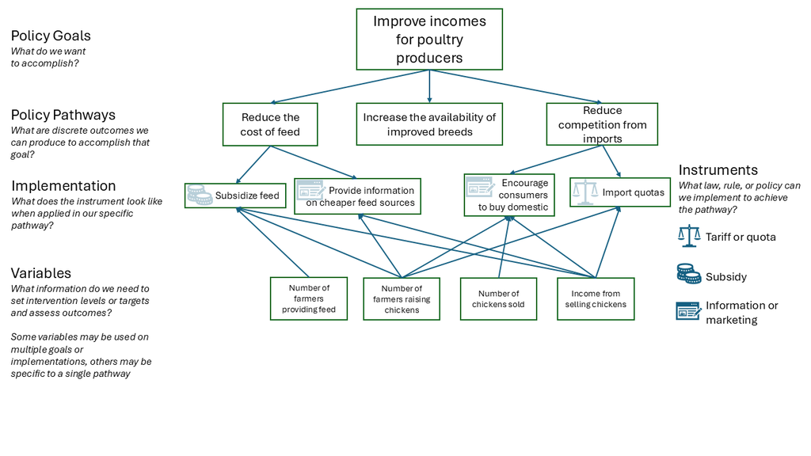

Illustration of the relationships between policy goals, pathways, and variables as applied to a simple example using poultry.

#### Creating Policy Goals, Setting Up Policy Pathways, and Determining Relevant Variables

##### Spreadsheet Summary

The app will automatically register all variables included in the input data files (see the Diagnostics tab), but it will only present statistics on the variables that have been included in the spreadsheets saved in the **Update** folder to avoid presenting too much information at once. The tables below summarize each spreadsheet and the minimum requirements for including a new set of variables and policy goal. Each table below summarizes the columns in each spreadsheet. Required columns are in **bold** text. Some columns are not strictly necessary for the app but are strongly recommended for full functionality and are indicated in *bold italic* text.

###### Indicators

This spreadsheet is where the information related to variables is stored. Variables that are not listed here will not be included in the app, even if they are listed in the other spreadsheets.

[output not shown]

Information in “survey_question_{year}” and “ques_text” is provided to users on the variable comparisons tab.

###### Policy_Pathways

This spreadsheet is used to construct the table on the “Policy Instruments by Goal” tab of the “Identifying Feasible Options” section. It is also used to set up the pathways that are used to filter the variables.

| Column Name | Definition |
| --- | --- |
| **pathwayID** | a number that uniquely identifies the Pathway (Sequential by row) |
| **goalName** | a short name to refer to the Policy Goal, will be repeated for each Pathway within a goal |
| *Pathway* | a descriptive definition of the Policy Pathway; optional, but necessary to have the option to filter the variable list to the pathway |
| *Instrument* | The category (e.g. subsidy, information campaign, tariff, quota) of the implementation |
| *Implementation* | A specific method for achieving the policy goal via the pathway (see definitions above) |
| Producer unit costs | An assessment of how the instrument would change the cost of making the final product (⬆, ⬇, ⬍, or =) |
| Final Prod Price | An assessment of how the instrument would affect the final product price received by the producer |
| Final prod Q | An assessment of how the instrument would affect the quantity of products available for sale |
| Prod Quality | An assessment of how the instrument would affect the average quality of the product. |
| Speed | An assessment of relative implementation time (text) |
| Feasibility | An assessment of easy or difficult the instrument will be to implement, given the realities of the legislative process and the anticipated levels of support or opposition from stakeholder groups |
| Evidence | If available, a link to a research paper or report supporting the information presented in the previous columns |

Additional columns may be added for additional ratings dimensions or to display more information in the table on the policy context tab.

###### Pathway_Names

An optional spreadsheet to display longer names on the tabs. If absent, the goalName shorthand will be used instead.

| Column Name | Definition |
| --- | --- |
| **goalName** | The name of the policy goal corresponding to the goalName column in the Policy_Pathways spreadsheet |
| **Policy.Goal** | The longer description of the policy goal |

###### Policy_Link

This spreadsheet connects policy pathways to variables.

| Column Name | Definition |
| --- | --- |
| **pathwayID** | The ID number for the Policy Pathway in Policy_Pathways. Use 0 to connect to a goal without specifying a pathway |
| **goalName** | The short name for the Policy Goal in Policy_Pathways |
| **shortName** | The short name for the Variable in the **indicators** spreadsheet. |

### Explanations by Tab

#### Policy Context

This page provides data and visualizations from both external sources and the CAS for understanding the agricultural and economic context in Cambodia. The Agricultural Sector Overview tab provides sector-wide information, while the Commodity Overviews provide information related to specific commodities. The colored **value boxes** provide statistics sourced from the World Bank’s [Open Data repository](https://data.worldbank.org/). Additional indicators can be added by downloading the csv files from their respective pages and placed in the Extdata subfolder in the main app directory. New datasets will be discovered and included automatically. Links back to the original indicator are provided on the value boxes for validation.

The commodities tab includes information of interest for specific crops or livestock species. The categories can be customized by editing the folders in the “Commodities” subfolder of the “Extdata” folder. The names of these folders will be used to determine the titles of each tab. Images downloaded from elsewhere can also be included; edit the “image_information.csv” file in each commodity directory to edit the titles and captions for the images.

### Identifying Feasible Options

This page provides a way to view and consider policies to address a given policy goal.

The **Stakeholder Mapping** tab displays diagrams of stakeholders in value chains that might be affected by new policies. Images created using diagramming applications are displayed here.

### Gather Evidence & Assess Data

To view estimates, begin by selecting a policy goal from the drop-down menu. Once a selection is made, the app will summarize all of the variables associated with that goal and present the Variable Summary Table and mapping options. Selecting a pathway will reduce the number of variables to just those identified as relevant to the policy instrument selected. The Mean/Total switch toggles between presenting national (or Zonal/Provincial) means to weighted totals.

Below the Variable Summary Table, the Detailed Information section, when expanded, shows sample sizes and other information saved as notes in the indicators spreadsheet.

##### Maps

A dropdown menu and a toggle switch will appear on the right side of the screen after a policy goal is chosen. The dropdown menu contains all the variables related to the policy/pathway, and the toggle switch can be used to swap between aggregation to the provincial level and the zone level. Selecting a variable will automatically draw the maps, the top showing the value from the latest available year, and the bottom showing the trend since the beginning of the survey series, when available. A third line plot shows the national-level trend since the beginning of the survey series.

##### Data Export

The table data can be downloaded as a csv file using the “Download Table Data” button. Maps can be saved by right clicking and saving the image, and the plot can be exported using the menu. The button with the symbol will download the data table for the first map.

### Interpreting Data Relationships

While the Gathering Evidence tab provides a general overview, the **Interpreting Data Relationships** page provides a more detailed look and side-by-side comparison of selected variables. This page can be used to visualize relationships between variables using a correlation heatmap. The heatmap shows the strength and direction of correlation between each pair of variables, with red indicating stronger positive correlations and blue stronger negative correlations. Hover over each dot to see the p-value of the correlation. Smaller values indicate stronger certainty that the association is not the result of chance variations in the data.

The organizational logic is the same as the Gather Evidence page, with options appearing after a policy goal is selected. Options to select two variables for a simple x-y comparison will appear, and those options can be narrowed further by selecting a policy pathway. A second button labeled “Show Heatmap” will also appear. Pressing this button will show a correlation heatmap across all the variables under the policy goal or the selected subset if a pathway is chosen.

All data processing will omit observations with empty or NA values for one of the variables, but the checkbox “omit 0s from Y variable” can be used filter the data further to include only observations where the selected Y variable has a non-zero value. This can be used to make the histograms easier to read or target a subpopulation of interest. For example, if the selected Y variable is “number of chickens vaccinated,” the unmodified results would include all chicken owners who did not vaccinate any of their chickens, while omitting 0’s would include results only for chicken owners who did vaccinate at least one chicken.

Data can also be grouped along subpopulations of interest. If a variable is included in the “groups.csv” spreadsheet in the raw data and has an entry in the “grouping_vars.xlsx” spreadsheet in the Update subfolder, it will appear in the list, and the results will compare values across the categories in that group.

Once you have selected variables and modifications, press the “Compare Variables” button to generate the graphs. Clicking the button above each histogram will show a table of the values (this table is omitted when viewing results at the household level due to the large number of entries it would have). A scatter/line graph at the bottom provides a quick assessment of the degree of correlation between the selected variables using a linear model. While this is not a substitute for rigorous statistical analysis, it can provide information about hypothesized relationships between variables that can be explored further using R or another statistical package using the raw data.

##### Data Export

Data can be downloaded in one of three ways:

- The “Download Selected Raw Data” will provide observations **for only the variables selected in the dropdown boxes**. The optional selections (omitting 0’s, administrative level, and grouping variables) will be honored in the data; therefore, selecting a level other than household will provide a summarized dataset.
- The “Download All Listed Raw Data” will provide the export format as above, but for **all of the variables related to the selected policy goal and pathway**.
- The buttons with the symbol will provide an spreadsheet version of the data table (for zone- and province-level summaries) with in a format that can be read by the app to reproduce the table on the **Policy Context** page if the file is placed in the proper commodity folder. Do not change the name of the file when using this feature.

### Additional Considerations & Sources for Evaluating Options

This page provides links to associated sources of data and information that can be used to create further figures. Edits to this table can be made by editing the Secondary_Sources.csv spreadsheet.

### App Diagnostics

In addition to the instructions you are currently reading, this page provides the **App Diagnostics** tab, which can be used to troubleshoot if the app stops working after an update. The app will check that the data and supporting spreadsheets are present and correctly formatted with the expected column names. In addition, it will present all of the variables found in the data files and report whether the metadata needed to incorporate them into the app are present. For a variable to show up, it must at least be present in the indicators list and be assigned to a policy goal. Assignment to a pathway is optional. Note that this is not the case for the hhid, province, and zone variables, which are used to identify observations. They should be present in all of the data files with the exception of groups and weights, which need only the unique household id.

### Advanced Users: Saving and Organizing Your Analysis Products and External Data

As mentioned in previous sections, one of the functions of the Overview tabs is to preserve analysis previously performed with the survey data in order to add context for subsequent analyses. We enable a wide variety of outputs to facilitate saving resources from other sources online.

#### Exporting Data and Analysis Products from the App

All tables and charts can be exported and re-used. Both the `ggplot` and `Plotly` packages are used to render plots. Charts in `ggplot` are simply rendered as images and can be exported by right-clicking on the chart and selecting “Save Image As…”, while `Plotly` charts have the toolbar and can be downloaded by clicking the picture icon. The chart can then be downloaded to the “Extdata” folder. Charts can be downloaded by using the download button, which exports the content as a raw csv file. It is important to retain the automatic name of the csv file, as it contains information that is used by the app to automatically title and caption the table.

#### External Data Sources

The World Bank data bank data can be saved by downloading the CSV file from the indicator page and placing the unzipped data file in the “World Bank” subfolder of “Extdata.”

Additional graphs or charts can be exported as images via screen capture or saving the resource to the folder, then captioned using the “image_info” csv file in the folder. Markdown formatting for links is supported, so you can generate a hyperlink like [this](http://www.google.com) by typing `[this](http://www.google.com)`.

Charts created from other sources of data in R can either be saved as an image using the `ggsave()` command for ggplots or exported as a an HTML file by using the package `htmlwidgets` (already part of this projects library) by using the `savewidget` command on a plot object (see the “Misc” folder for examples). There are two good reasons to save a plot as an HTML file instead of an image: no tinkering with image resolution or scale is needed for the plot to render well, and it preserves the additional functionality provided by the `Plotly` package. A comparison of methods is currently visible on the Poultry commodity tab.

#### Using the “Agricultural Sector Overview” and “Commodity” tabs

The “Agricultural Sector Overview” tab looks in the “Overview” and “World Bank” subfolders of “Extdata” for relevant objects. Each commodity tab is generated from the subfolders in the “Commodities” subfolder, with the tab names being drawn from the folder names.

#### Image, plot, and table organization

Right now, the app defaults to putting tables first and figures second. Figures are arranged in the order they appear in the image_info csv file, with unlisted images/charts being loaded last.